# N741 Spring 2018 - Homework 7

Homework 7 - DUE WED April 11, 2018

Rosemary Kinuthia

April 6, 2018

## Homework 7

Use these variables from HELP dataset for Homework 07

|  | Variable Label |
| --- | --- |
| age | Age at baseline (in years) |
| female | Gender of respondent |
| pss_fr | Perceived Social Support - friends |
| homeless | One or more nights on the street or shelter in past 6 months |
| pcs | SF36 Physical Composite Score - Baseline |
| mcs | SF36 Mental Composite Score - Baseline |
| cesd | CESD total score - Baseline |
| cesd_gte16 | Indicator of Depression |
| mcs_lt45 | Indicator of Poor Mental Health |

## Homework 7 Assignment

```r
#Load packages needed for Homework 7
library(rpart)
library(partykit)
library(reshape2)
library(party)
library(tidyverse)
library(randomForestSRC)
library(ggRandomForests)
```

### **PROBLEM 1: Regression Tree for MCS**

Using the code above, fit a regression tree model where the `mcs` is the outcome and the `cesd` is the predictor and complete the following:

- fit a regression tree to the `mcs` based on only the `cesd` scores from the `h1` dataset;
- display the results
- plot the cross-validated results
- provide a summary of the model fit
- and plot the regression tree

```r
# fit a regression tree model to the mcs as the outcome
# and using the cesd as the only predictor
fitmcs <- rpart::rpart(mcs ~ cesd, data = h1)
rpart::printcp(fitmcs) # Display the results
```

```
##
## Regression tree:
## rpart::rpart(formula = mcs ~ cesd, data = h1)
##
## Variables actually used in tree construction:
## [1] cesd
##
## Root node error: 74512/453 = 164.48
##
## n= 453
##
##         CP nsplit rel error  xerror     xstd
## 1 0.325298      0   1.00000 1.00384 0.054675
## 2 0.081349      1   0.67470 0.69582 0.046808
## 3 0.066496      2   0.59335 0.63994 0.045806
## 4 0.012496      3   0.52686 0.55821 0.040217
## 5 0.010000      4   0.51436 0.55896 0.040694
```

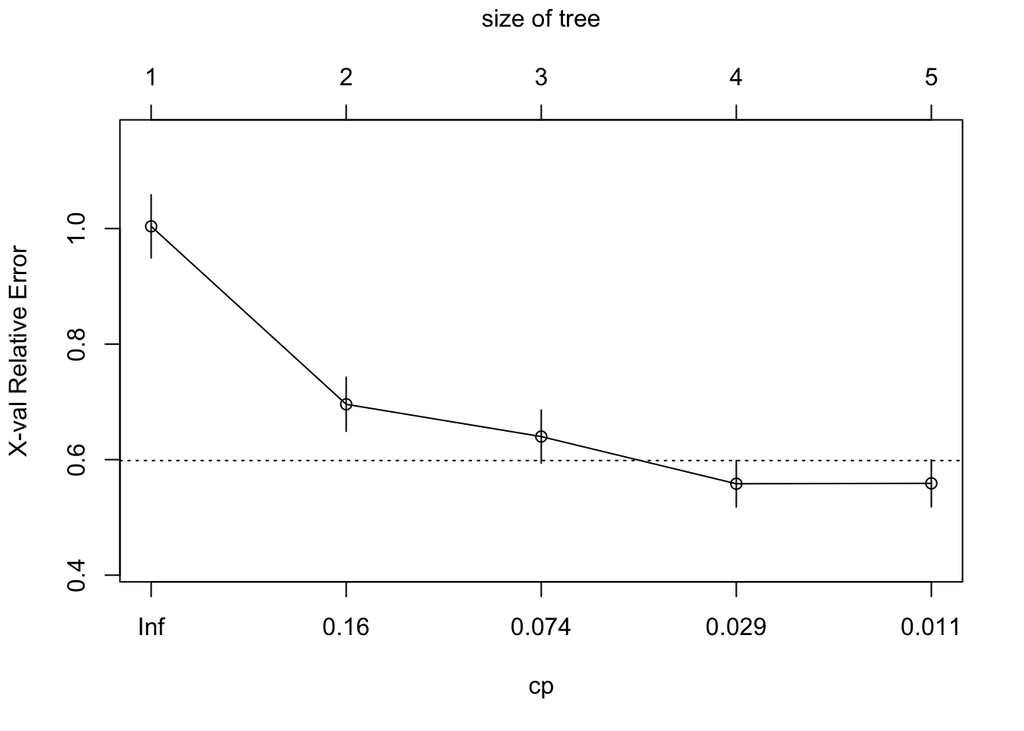

```r
rpart::plotcp(fitmcs) # Visualize cross-validation results
```

```r
summary(fitmcs) # Detailed summary of fit
```

```
## Call:
## rpart::rpart(formula = mcs ~ cesd, data = h1)
##   n= 453
##
##           CP nsplit rel error    xerror       xstd
## 1 0.32529813      0 1.0000000 1.0038378 0.05467458
## 2 0.08134904      1 0.6747019 0.6958172 0.04680821
## 3 0.06649553      2 0.5933528 0.6399356 0.04580625
## 4 0.01249609      3 0.5268573 0.5582119 0.04021732
## 5 0.01000000      4 0.5143612 0.5589562 0.04069373
##
## Variable importance
## cesd
##  100
##
## Node number 1: 453 observations,    complexity param=0.3252981
##   mean=31.67668, MSE=164.4847
##   left son=2 (285 obs) right son=3 (168 obs)
##   Primary splits:
##       cesd < 29.5 to the right, improve=0.3252981, (0 missing)
##
## Node number 2: 285 observations,    complexity param=0.06649553
##   mean=26.06057, MSE=100.1894
##   left son=4 (100 obs) right son=5 (185 obs)
##   Primary splits:
##       cesd < 42.5 to the right, improve=0.17352, (0 missing)
##
## Node number 3: 168 observations,    complexity param=0.08134904
##   mean=41.20401, MSE=129.2805
##   left son=6 (122 obs) right son=7 (46 obs)
##   Primary splits:
##       cesd < 15.5 to the right, improve=0.2790834, (0 missing)
##
## Node number 4: 100 observations
##   mean=20.38941, MSE=43.95751
##
## Node number 5: 185 observations
##   mean=29.12606, MSE=103.8029
##
## Node number 6: 122 observations
##   mean=37.51566, MSE=103.6988
##
## Node number 7: 46 observations,    complexity param=0.01249609
##   mean=50.98616, MSE=65.35702
##   left son=14 (26 obs) right son=15 (20 obs)
##   Primary splits:
##       cesd < 9.5  to the right, improve=0.3097046, (0 missing)
##
## Node number 14: 26 observations
##   mean=47.04024, MSE=67.29195
##
## Node number 15: 20 observations
##   mean=56.11586, MSE=16.28645
```

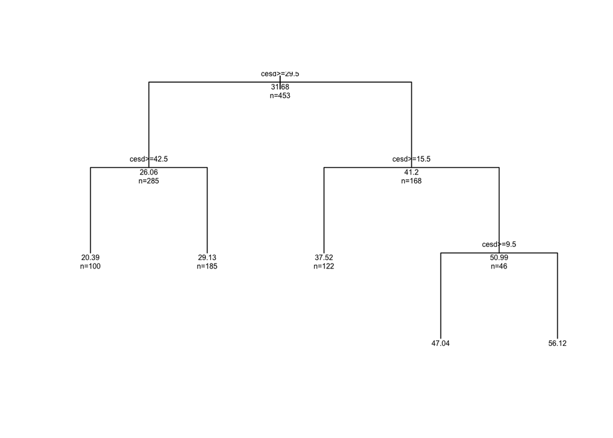

```r
# plot tree
plot(fitmcs, uniform = TRUE, compress = FALSE)
text(fitmcs, use.n = TRUE, all = TRUE, cex = 0.5)
```

### **PROBLEM 2: Matrix Scatterplot of Other Variables with MCS**

Using the code above as a guide,swap out `mcs` for `cesd` and redo the scatterplots compared to the `mcs`. HINT: You can begin with the data subset `h1a`, but you will need to modify the code for `h1m` and for the `ggplot()` code lines.

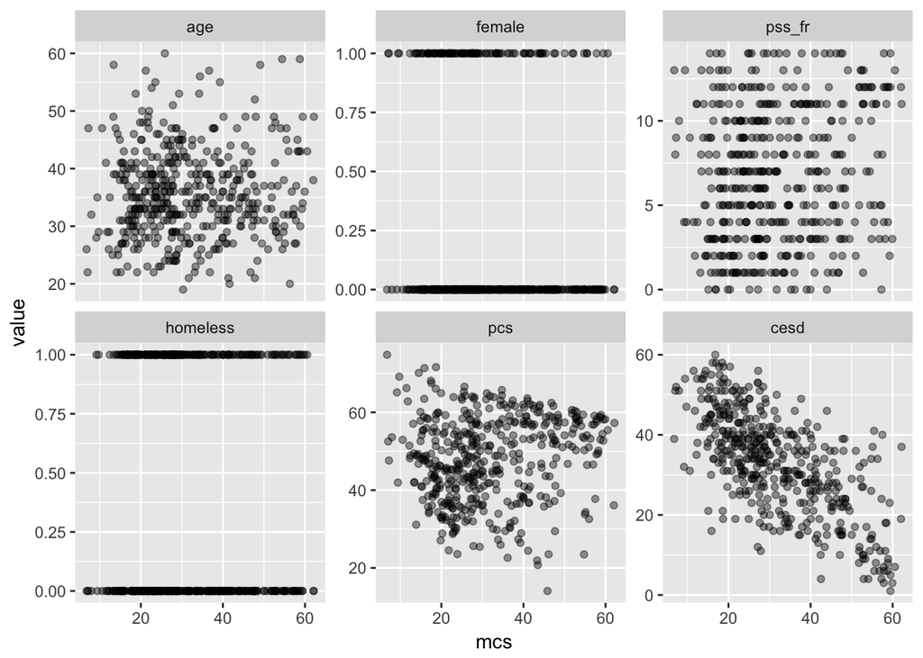

```r
# all vars except the dichotomous cesd_gte16 and mcs_lt45
h1a <- h1[,1:7]

# Melt the other variables down and link to mcs
h1m <- reshape2::melt(h1a, id.vars = "mcs")

# Plot panels for each covariate
ggplot(h1m, aes(x=mcs, y=value)) +
  geom_point(alpha=0.4)+
  scale_color_brewer(palette="Set2")+
  facet_wrap(~variable, scales="free_y", ncol=3)
```

### **PROBLEM 3: Regression Tree for MCS Using Rest of Variables**

Using the code above as a guide, swap out `mcs` for `cesd` and redo the regression tree for `mcs` using the rest of the variables in the data subset `h1a`.

```r
# fit a regression tree with all vars
fitall <- rpart::rpart(mcs ~ ., data = h1a)

# equivalent code statement without the shorthand
# using the period for the "rest of the variables"
# this time each variable to be included is listed
# individually putting a plus + in between each
# variable added to the model

fitall <- rpart::rpart(mcs~ age + female + pss_fr +
                              homeless + pcs + cesd,
                              data = h1a)

# Now let's look at fitall
rpart::printcp(fitall) # Display the results
```

```
##
## Regression tree:
## rpart::rpart(formula = mcs ~ age + female + pss_fr + homeless +
##     pcs + cesd, data = h1a)
##
## Variables actually used in tree construction:
## [1] cesd pcs
##
## Root node error: 74512/453 = 164.48
##
## n= 453
##
##         CP nsplit rel error  xerror     xstd
## 1 0.325298      0   1.00000 1.00455 0.054665
## 2 0.081349      1   0.67470 0.69502 0.046745
## 3 0.066496      2   0.59335 0.64622 0.045287
## 4 0.017717      3   0.52686 0.56366 0.040613
## 5 0.015767      4   0.50914 0.56559 0.040336
## 6 0.012496      5   0.49337 0.56824 0.040370
## 7 0.012258      6   0.48088 0.57406 0.041279
## 8 0.010000      7   0.46862 0.58098 0.041580
```

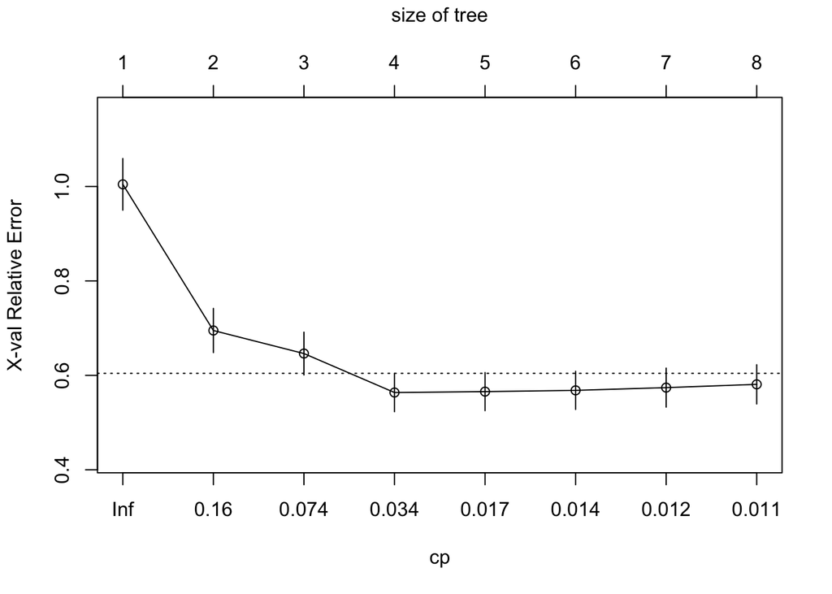

```r
rpart::plotcp(fitall) # Visualize cross-validation results
```

```r
summary(fitall) # Detailed summary of fit
```

```
## Call:
## rpart::rpart(formula = mcs ~ age + female + pss_fr + homeless +
##     pcs + cesd, data = h1a)
##   n= 453
##
##           CP nsplit rel error    xerror       xstd
## 1 0.32529813      0 1.0000000 1.0045478 0.05466529
## 2 0.08134904      1 0.6747019 0.6950200 0.04674484
## 3 0.06649553      2 0.5933528 0.6462180 0.04528689
## 4 0.01771736      3 0.5268573 0.5636589 0.04061322
## 5 0.01576737      4 0.5091399 0.5655929 0.04033625
## 6 0.01249609      5 0.4933726 0.5682405 0.04037050
## 7 0.01225792      6 0.4808765 0.5740602 0.04127898
## 8 0.01000000      7 0.4686186 0.5809767 0.04157976
##
## Variable importance
##   cesd    pcs    age pss_fr
##     83     14      1      1
##
## Node number 1: 453 observations,    complexity param=0.3252981
##   mean=31.67668, MSE=164.4847
##   left son=2 (285 obs) right son=3 (168 obs)
##   Primary splits:
##       cesd   < 29.5     to the right, improve=0.325298100, (0 missing)
##       pcs    < 49.46132 to the left,  improve=0.064711670, (0 missing)
##       pss_fr < 10.5     to the left,  improve=0.039318510, (0 missing)
##       female < 0.5      to the right, improve=0.014091560, (0 missing)
##       age    < 42.5     to the left,  improve=0.005473724, (0 missing)
##   Surrogate splits:
##       pcs < 56.34591 to the left,  agree=0.669, adj=0.107, (0 split)
##       age < 57.5     to the left,  agree=0.631, adj=0.006, (0 split)
##
## Node number 2: 285 observations,    complexity param=0.06649553
##   mean=26.06057, MSE=100.1894
##   left son=4 (100 obs) right son=5 (185 obs)
##   Primary splits:
##       cesd   < 42.5     to the right, improve=0.173520000, (0 missing)
##       pcs    < 24.47511 to the right, improve=0.057879990, (0 missing)
##       pss_fr < 10.5     to the left,  improve=0.015219690, (0 missing)
##       age    < 22.5     to the right, improve=0.005742931, (0 missing)
```

[output cut: 70 more lines]

```
##
## Node number 13: 112 observations
##   mean=38.49859, MSE=98.40465
##
## Node number 14: 26 observations
##   mean=47.04024, MSE=67.29195
##
## Node number 15: 20 observations
##   mean=56.11586, MSE=16.28645
##
## Node number 22: 171 observations
##   mean=29.16748, MSE=95.51594
##
## Node number 23: 7 observations
##   mean=40.8217, MSE=76.41866
```

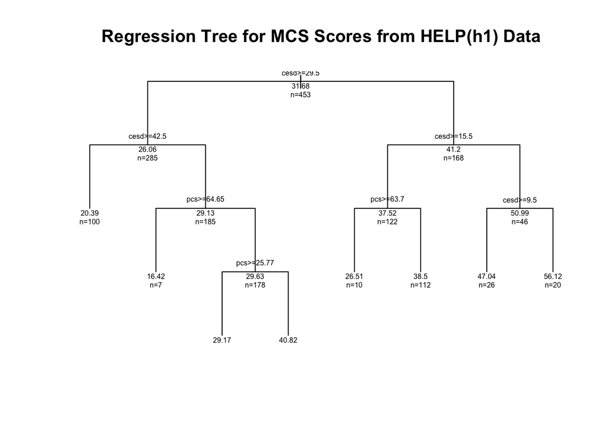

```r
plot(fitall, uniform = TRUE, compress = FALSE, main = "Regression Tree for MCS Scores from HELP(h1) Data")
text(fitall, use.n = TRUE, all = TRUE, cex = 0.5)
```